# UNIT07B：離散機率的應用案例

中山大學管理學院 卓雍然

2022-03-30 14:40:33

💡 學習重點：離散機率的定義  
■ `Binomial[n, p]`: 重複發生機率為`p`的實驗`n`次，其發生次數的分佈  
■ `Geomtric[p]`: 重複發生機率為`p`的實驗，第一次發生前失敗次數的分佈  
■ `NBinomial[n, p]`: 重複發生機率為`p`的實驗，第`n`次發生前失敗次數的分佈  
■ `Poisson[`$\lambda$`]`: 期望值為$\lambda$的小機率事件發生次數的分佈

```r
pacman::p_load(dplyr, vcd)
```

### 【1】被馬踢死 Death by Horse Kick

**資料** `HorseKick`:每一個軍團、每年被馬踢死的人數

```r
par(mfrow=c(1,1), cex=0.7)
HorseKicks
```

```
nDeaths
  0   1   2   3   4
109  65  22   3   1
```

**檢定**：這一份數據符合Poisson分佈嗎？

```r
fit = goodfit(HorseKicks, type = "poisson")
summary(fit)
```

```
     Goodness-of-fit test for poisson distribution

                     X^2 df P(> X^2)
Likelihood Ratio 0.86822  3  0.83309
```

```r
# H0:沒有顯著差異
```

`p=0.833`：數據與Poisson沒有顯著差異

**係數**：What is the $\lambda$?

```r
fit$par #參數
```

```
$lambda
[1] 0.61
```

**應用**：`nDeath >= 2` 的機率是？

```r
1 - ppois(1, fit$par$lambda) #到1的機率
```

```
[1] 0.12521
```

🧙 問題討論：  
如果保險公司想要為國防部設計一個被馬踢死的保險：  
■ 如果你只要只靠`HorseKick`這一份數據，每一軍團每年被馬踢死的次數超過5次的機率是多？ 不知道  
■ 如果我們將數據fit到理論分布上面，根據理論分佈，被馬踢死的次數超過5次的機率是多？  
■ 妳想要計算風險成本的話，以上哪一種做法比較合理呢？ 第2種

What is the probability of `nDeath >= 5`?

```r
1 - ppois(4, fit$par$lambda)
```

```
[1] 0.00042497
```

```r
ppois(6, fit$par$lambda) - ppois(2, fit$par$lambda)  #被馬踢死的人數大於等於3小於等於6的機率
```

```
[1] 0.024111
```

```r
dpois(3,fit$par$lambda)+dpois(4,fit$par$lambda)+dpois(5,fit$par$lambda)+dpois(6,fit$par$lambda)
```

```
[1] 0.024111
```

```r
dpois(3:6,fit$par$lambda) %>% sum
```

```
[1] 0.024111
```

```r
1-(dpois(0,fit$par$lambda)+dpois(1,fit$par$lambda)+dpois(2,fit$par$lambda)+dpois(3,fit$par$lambda)+dpois(4,fit$par$lambda))
```

```
[1] 0.00042497
```

### 【2】“May” in Federalist Papers

**資料** `Federalist`：某份聯邦文件中，每一個段落出現”may”這個字的次數

```r
Federalist
```

```
nMay
  0   1   2   3   4   5   6
156  63  29   8   4   1   1
```

**檢定**：這一份數據符合Poisson分佈嗎？

```r
fit <- goodfit(Federalist, type = "poisson") #NO
summary(fit)
```

```
     Goodness-of-fit test for poisson distribution

                    X^2 df   P(> X^2)
Likelihood Ratio 25.243  5 0.00012505
```

它符合負二項(Negtive Binomial)分佈嗎？

```r
fit = goodfit(Federalist, type = "nbinomial") #YES
summary(fit)
```

```
     Goodness-of-fit test for nbinomial distribution

                   X^2 df P(> X^2)
Likelihood Ratio 1.964  4  0.74238
```

**係數**：負二項(Negtive Binomial)的係數是？

```r
fit$par
```

```
$size
[1] 1.1863

$prob
[1] 0.64376
```

**分佈**：How does the distribution looks like?

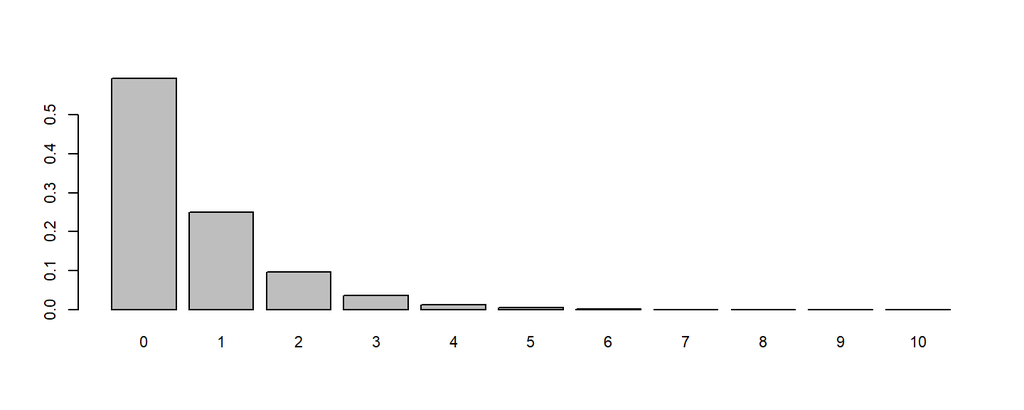

```r
par=c(margin=c(3,3,3,1),cex=0.7)
dnbinom(0:10, fit$par$size, fit$par$prob) %>% barplot(names=0:10)
```

**機率**：What is the probability that `2 <= nMay <= 6`?

```r
pnbinom(6,fit$par$size,fit$par$prob)-pnbinom(1,fit$par$size,fit$par$prob)
```

```
[1] 0.15526
```

💡 學習重點：離散機率的應用步驟  
1. 檢定分佈的種類  
2. 估計分佈的參數  
3. 推論事件的機率